# HW7

Claire

2018年11月13日

# 11.18

## a.

```r
n1<-64
u1<-27.5
sd1<-2
n2<-100
u2<-24
sd2<-2
se2<-sd2/sqrt(100)
se2
```

```
## [1] 0.2
```

## b.

##### 0.3201562

```r
sqrt((sd1^2/n1)+(sd2^2/n2))
```

```
## [1] 0.3201562
```

# 11.32

## a. 3.839552~5.160448

```r
n1<-25
mu1<-4.5
sd1<-1.6
se1<-1.6/sqrt(n1)
t1<-qt((1-0.95)/2,df=25-1,lower.tail=F)
t1
```

```
## [1] 2.063899
```

```r
low.c<-mu1-t1*se1;low.c
```

```
## [1] 3.839552
```

```r
high.c<-mu1+t1*se1;high.c
```

```
## [1] 5.160448
```

## b. 7.321622~8.878378

```r
n2<-23
mu2<-8.1
sd2<-1.8
se2<-sd2/sqrt(n2)
t2<-qt((1-0.95)/2,df=n2-1,lower.tail=F)
t2
```

```
## [1] 2.073873
```

```r
low.c<-mu2-t2*se2;low.c
```

```
## [1] 7.321622
```

```r
high.c<-mu2+t2*se2;high.c
```

```
## [1] 8.878378
```

## c.

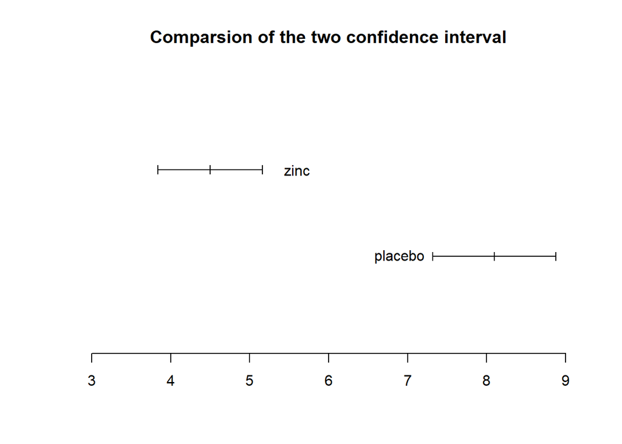

```r
plot(c(0,3),type='n',xlim=c(3,9),xlab='',ylab='',axes=F,
     main='Comparsion of the two confidence interval')

lines(c(3.839552,5.160448),c(2,2))
text(5.6,2,labels='zinc')
lines(c(3.839552,3.839552),c(1.95,2.05))
lines(c(4.5,4.5),c(1.95,2.05))
lines(c(5.160448,5.160448),c(1.95,2.05))

lines(c( 7.321622,8.878378),c(1,1))
text(6.9,1,labels='placebo')
lines(c( 7.321622, 7.321622),c(0.95,1.05))
lines(c(8.1,8.1),c(0.95,1.05))
lines(c(8.878378,8.878378),c(0.95,1.05))

axis(1)
```

## d.

##### 這是一個合理的結論，因為兩條線之間沒有交疊，代表雙方的差異是明顯的

## e.

##### 因為要確定資料是鐘形曲線，(a),(b)才能用t分配算信賴區間

# 11.50

## a.

##### 0.8171697~2.78283 ，這個區間代表有95%的信心水準真正的理想身高與現實身高差異會落在0.8171697~2.78283之間

```r
n<-20;mu<-1.8;sd<-2.1
se<-sd/sqrt(n)
t<-qt((1-0.95)/2,df=n-1,lower.tail=F)
low.c<-mu-t*se;low.c
```

```
## [1] 0.8171697
```

```r
high.c<-mu+t*se;high.c
```

```
## [1] 2.78283
```

## b.

##### 樣本資料呈現鐘形分布，且是隨機抽樣的；或是不是鐘形分布但資料龐大

## c.

##### 不正確，一方面沒有論述到在多少信心水準下，另一方面不能說全部的女生都這樣，而應該說女生中平均來說想要變得比現實還高

## d.

##### 不適合，那樣的方法需要很大的樣本數

# 11.60

```r
g1<-c(72,84,66,72,62,84,76,60)
n1<-8;mu1<-sum(g1)/n1;sd1<-sd(g1)
g2<-c(62,72,60,63,75,64,60,52,64,80,68,64)
n2<-12;mu2<-sum(g2)/n2;sd2<-sd(g2)
se<-sqrt((sd1^2/n1)+(sd2^2/n2))
t<-qt((1-0.95)/2,df=n1-1,lower.tail=F)
mu<-mu1-mu2
low.c<-mu-t*se;low.c
```

```
## [1] -2.522048
```

```r
high.c<-mu+t*se;high.c
```

```
## [1] 15.85538
```

```r
t.test(g1, g2, alternative = 'two.sided', var.equal = F, paired = F, conf.level = 0.95)
```

```
##
##  Welch Two Sample t-test
##
## data:  g1 and g2
## t = 1.7156, df = 13.014, p-value = 0.1099
## alternative hypothesis: true difference in means is not equal to 0
## 95 percent confidence interval:
##  -1.727387 15.060720
## sample estimates:
## mean of x mean of y
##  72.00000  65.33333
```

## b.

```r
sp<-sqrt(((n1-1)*sd1^2+(n2-1)*sd2^2)/(n1+n2-2))
se<-sp*sqrt((1/n1)+(1/n2))
t<-qt((1-0.95)/2,df=n1+n2-2,lower.tail=F)
low.c<-mu-t*se;low.c
```

```
## [1] -1.165182
```

```r
high.c<-mu+t*se;high.c
```

```
## [1] 14.49852
```

## c.

# 11.78

## a.

##### 6.410593

```r
n1<-16;n2<-16
d1<-113.75;sd1<-22.64
d2<-99.87;sd2<-12.04
se<-sqrt((sd1^2/n1)+(sd2^2/n2))
se
```

```
## [1] 6.410593
```

## b.

##### 0.5852443~27.17476

```r
t<-qt((1-0.95)/2,df=22,lower.tail=F)
d<-d1-d2
low.c<-d-t*se;low.c
```

```
## [1] 0.5852443
```

```r
high.c<-d+t*se;high.c
```

```
## [1] 27.17476
```

## c.

##### 可以，因為兩者的差異在95%信心水準下都是>0的，所以證明有差異。

## d.

##### 資料會呈現鐘型分布，因為大部分的人都是在接近的的時間下完成實驗。

# 11.80

## a.

##### 是paired data，因為慣用手與不慣用手夾取豆子數量之間存在著相關，是成對的資料。

## b.

##### 因為夾豆子的順序可能會影響後面那隻手夾豆子的表現(例如疲累或是經驗學習)，所以要交錯先後順序減弱不平衡。

## c.

##### -0.04018838~2.173522

```r
g<-c(4,4,5,1,-2,0,2,4,-3,0,0,0,-2,2,1)
d<-mean(g);sd<-sd(g)
se<-sd/sqrt(15)
t<-qt((1-0.9)/2,df=14,lower.tail=F)
low.c<-d-t*se;low.c
```

```
## [1] -0.04018838
```

```r
high.c<-d+t*se;high.c
```

```
## [1] 2.173522
```

## d.

##### 慣用手夾豆子的能力在90%信心水準下沒有顯著的差異，因為區間包含0。

# 實習

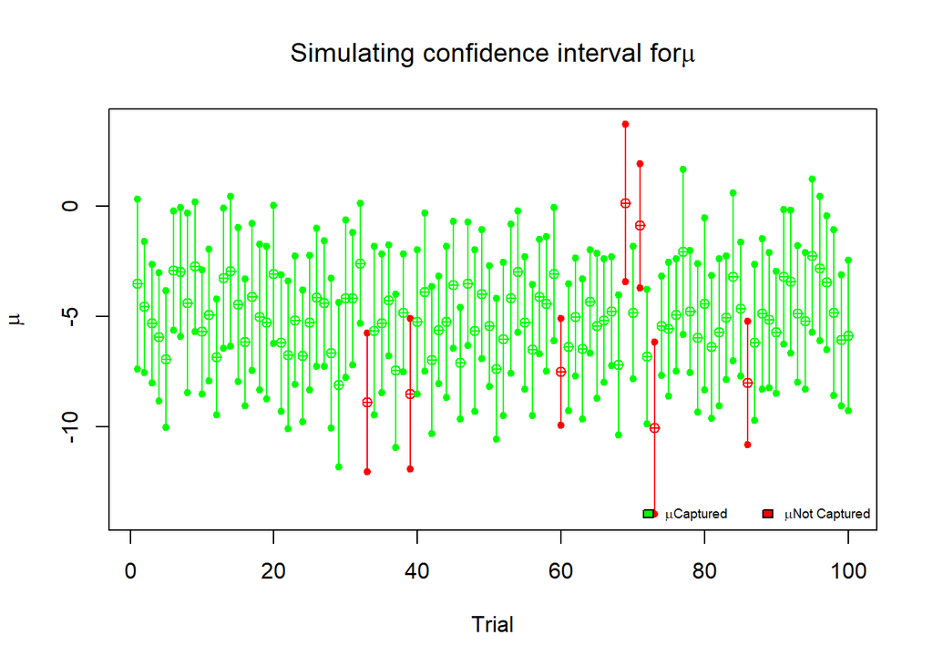

```
## $Trial
## [1] 100
##
## $Sample.Size
## [1] 30
##
## $Population.mean1
## [1] 50
##
## $Population.mean2
## [1] 55
##
## $Population.sd1
## [1] 5
##
## $Population.sd2
## [1] 7
##
## $Confidence
## [1] 0.95
##
## $No.Captured
## [1] 7
```

```r
Sim_CI<-function(n,mu1,sd1,mu2,sd2,m,conf.level){

  prob<-(1-conf.level)/2
  t.value=qt(prob,df=n-1,lower.tail=FALSE)

  mean.x=c()
  se.x=c()


  CI.half=c()
  CI.Up=c()
  CI.Lower=c()
  Check=c()

  #Mumeanltiple sampling
  for (i in 1:m){

    #one sampling 1
    x1<-rnorm(n,mean=mu1,sd=sd1)
    x2<-rnorm(n,mean=mu2,sd=sd2)
    x<-x1-x2
    mean.x[i]<-mean(x)
    se.x[i]<-sd(x)/sqrt(n)

    #calculate one confidence interval
    CI.half[i]<-t.value*se.x[i]
    CI.Up[i]<-mean.x[i]+CI.half[i]
    CI.Lower[i]<-mean.x[i]-CI.half[i]
    if(CI.Up[i]>mu1-mu2 & CI.Lower[i]<mu1-mu2) Check[i]<-1 else Check[i]<-0
  }

  plot(c(CI.Up,CI.Lower),type="n",pch=19,xlim=c(1,m),xlab="Trial",ylab=expression(mu))  #n=甚麼都不畫
  abline(h=mu,col="blue")

  #check weather each confidence interval captures the population mean (mu)
  for (i in 1:m){
    if (Check[i]==1){
      points(i, mean.x[i], col="green", pch=10)
      points(i, CI.Up[i], col="green", pch=20)
      points(i, CI.Lower[i], col="green", pch=20)
      lines(c(i,i),c(CI.Lower[i],CI.Up[i]), col="green", pch=19)

    }else{
      points(i, mean.x[i], col="red", pch=10)
      points(i, CI.Up[i], col="red", pch=20)
      points(i, CI.Lower[i], col="red", pch=20)
      lines(c(i,i),c(CI.Lower[i],CI.Up[i]), col="red", pch=19)
    }
  }


  title(expression(paste("Simulating confidence interval for",mu)))

  legend("bottomright",cex=0.6,bty = "n",ncol = 2,
         c(expression(paste(mu,"Captured")),expression(paste(mu,"Not Captured"))),
         fill = c("green","red"))

  No.Captured = m-sum(Check)
  RESULT = list(Trial=m, Sample.Size=n,
                Population.mean1=mu1,Population.mean2=mu2,Population.sd1=sd1,Population.sd2=sd2,
                Confidence=conf.level,
                No.Captured=No.Captured)

  return(RESULT)
}

Sim_CI(n=30, m=100, mu1=50, sd1=5, mu2=55,sd2=7,conf.level=0.95)
```